# Final Project: Analyzing the Relationship between Covid Rates and Mask Usage in the USA

Group 2: Lauren Cunild, Alan Yang, Dawit Dean, Wenqi Li, Zach Karol, Bowen You

12/1/2021

First, we need to download our data from the NYT data set. We are using the rolling average data for deaths and cases, and the mask use by county data set. Next, we need to join the data sets, so that we can better analyze whether cases and deaths do depend upon the mask use in the county, or state.

```r
# Import packages
library(tidyverse)
```

```r
library(dplyr)
library(maps)
library(lubridate)
# Import data
mask_use <- read.csv('https://raw.githubusercontent.com/nytimes/covid-19-data/master/mask-use/mask-use-by-county.csv')
rolling_avg <- read.csv('https://raw.githubusercontent.com/nytimes/covid-19-data/master/rolling-averages/us-counties-2021.csv')
```

```r
# Extract county id code
rolling_avg_new <- mutate(rolling_avg,geoid = as.integer(substr(geoid,5,9)))
# Mutate to rename county id code, so that the two data sets are consistent
rolling_avg_new <- rename(rolling_avg_new, COUNTYFP = geoid)
# create a new data set with both the cases/deaths averages and mask use data by county
data <- inner_join(rolling_avg_new, mask_use, by="COUNTYFP")
head(data)
```

```
##         date COUNTYFP     county   state cases cases_avg cases_avg_per_100k
## 1 2021-01-01    56045     Weston Wyoming     0      2.00              28.87
## 2 2021-01-01    56043   Washakie Wyoming     0      8.43             107.99
## 3 2021-01-01    56041      Uinta Wyoming     0     10.38              51.30
## 4 2021-01-01    56039      Teton Wyoming     0     12.38              52.74
## 5 2021-01-01    56037 Sweetwater Wyoming     0     18.25              43.10
## 6 2021-01-01    56035   Sublette Wyoming     0      2.25              22.89
##   deaths deaths_avg deaths_avg_per_100k NEVER RARELY SOMETIMES FREQUENTLY
## 1      0       0.00                0.00 0.142  0.129     0.148      0.207
## 2      0       0.78                9.97 0.204  0.155     0.069      0.285
## 3      0       0.00                0.00 0.098  0.278     0.154      0.207
## 4      0       0.22                0.95 0.095  0.157     0.160      0.247
## 5      0       0.14                0.34 0.061  0.295     0.230      0.146
## 6      0       0.14                1.45 0.223  0.111     0.061      0.231
##   ALWAYS
## 1  0.374
## 2  0.287
## 3  0.264
## 4  0.340
## 5  0.268
## 6  0.374
```

We can now look at the mask frequency data by county, to identify any trends in our data set. We want to see which areas have higher and lower mask usage, and whether it depends on other factors, such as geographic location.

```r
# Extract mask use data
mask_data <- data[c("date", "COUNTYFP", "county", "state","NEVER","RARELY", "SOMETIMES", "FREQUENTLY", "ALWAYS")]
```

```r
# filter for 3 different dates, approx 6 months apart
mask_data_filtered <- mask_data %>% mutate(date = ymd(date)) %>% filter (date == as.Date("2021-01-21")| date == as.Date('2021-06-09')| date == as.Date('2021-11-17'))
```

Next, we created a new variable called `mask_frequency`, which assigns a score to each county based upon the reported mask use. We gave never a score of 0.2, rarely 0.4, sometimes 0.6, frequently 0.8 and always 1. We then multiplied these scores by the probability, to give an approximate percentage of the amount of time people were masks for in the county, which higher scores corresponding to a higher reported mask usage.

```r
# create new df to assign mask usage score to each county
mask_freq_filtered <- mask_data_filtered %>% mutate(mask_frequency = 1*mask_data_filtered$ALWAYS + 0.8*mask_data_filtered$FREQUENTLY + 0.6*mask_data_filtered$SOMETIMES + 0.4*mask_data_filtered$RARELY + 0.2*mask_data_filtered$NEVER)
# display data in descending order
mask_freq_filtered <- arrange(mask_freq_filtered, desc(mask_frequency))
mask_freq_filtered <- select(mask_freq_filtered, c('date', 'COUNTYFP','county', 'state', 'mask_frequency'))
head(mask_freq_filtered)
```

```
##         date COUNTYFP county      state mask_frequency
## 1 2021-01-21    36123  Yates   New York         0.9698
## 2 2021-06-09    36123  Yates   New York         0.9698
## 3 2021-11-17    36123  Yates   New York         0.9698
## 4 2021-01-21     6033   Lake California         0.9642
## 5 2021-06-09     6033   Lake California         0.9642
## 6 2021-11-17     6033   Lake California         0.9642
```

We also need to examine how the number of cases and deaths vary by county. To do this, we will use the number of cases and deaths reported per 100k of the population, to standardize across our data set.

```r
# create df for cases and deaths avg per 100k in each county on chosen date
cases_data <- data[c("date", "COUNTYFP", "county", "state","cases_avg_per_100k", "deaths_avg_per_100k")]
cases_data_filtered <- cases_data %>% mutate(date = ymd(date)) %>% filter (date == as.Date("2021-01-21") | date == as.Date('2021-06-09') | date == as.Date('2021-11-17'))
head(cases_data_filtered)
```

```
##         date COUNTYFP     county   state cases_avg_per_100k deaths_avg_per_100k
## 1 2021-01-21    56045     Weston Wyoming              14.44                0.00
## 2 2021-01-21    56043   Washakie Wyoming              20.13                1.83
## 3 2021-01-21    56041      Uinta Wyoming              56.50                0.71
## 4 2021-01-21    56039      Teton Wyoming             163.17                0.61
## 5 2021-01-21    56037 Sweetwater Wyoming              40.49                0.67
## 6 2021-01-21    56035   Sublette Wyoming              10.17                0.00
```

Now that we have looked at the two data sets individually, we want to combine them, so that we can answer our question of whether mask use does affect the number of deaths and cases reported.

```r
# Join previous two df
cases_mask_data <- right_join(cases_data_filtered, mask_freq_filtered, by=c ("COUNTYFP", "date","county", "state"))
head(cases_mask_data)
```

```
##         date COUNTYFP     county   state cases_avg_per_100k deaths_avg_per_100k
## 1 2021-01-21    56045     Weston Wyoming              14.44                0.00
## 2 2021-01-21    56043   Washakie Wyoming              20.13                1.83
## 3 2021-01-21    56041      Uinta Wyoming              56.50                0.71
## 4 2021-01-21    56039      Teton Wyoming             163.17                0.61
## 5 2021-01-21    56037 Sweetwater Wyoming              40.49                0.67
## 6 2021-01-21    56035   Sublette Wyoming              10.17                0.00
##   mask_frequency
## 1         0.7084
## 2         0.6592
## 3         0.6528
## 4         0.7154
## 5         0.6530
## 6         0.6844
```

As there are over 3,000 counties, we will group the counties by state, to answer our hypothesis on a state-wide level.

Looking at the average number of cases by state:

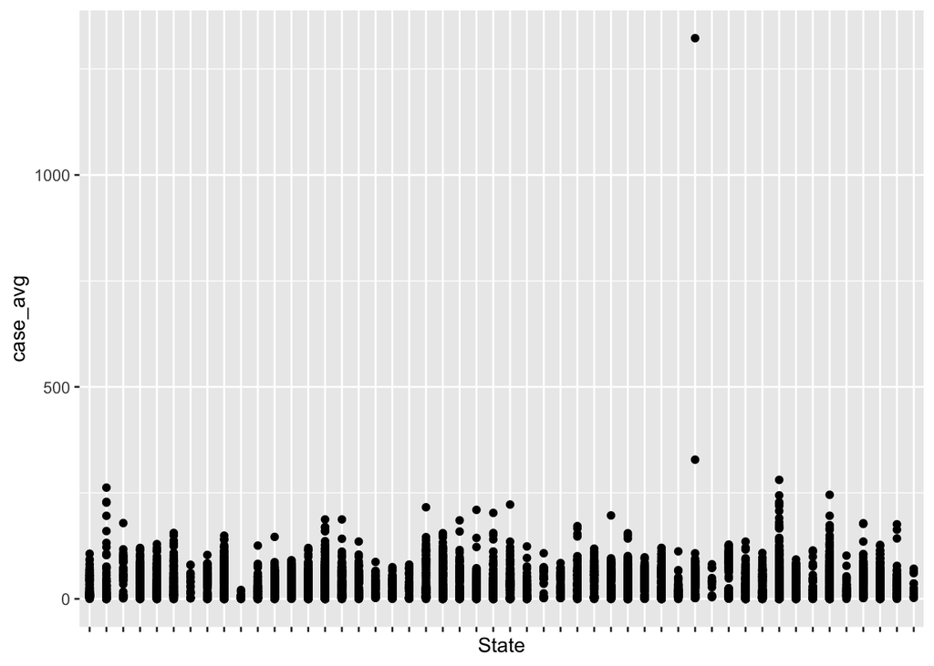

```r
cases_mask_data %>%
  mutate(State = fct_lump(state))%>%
  group_by(State)%>%
  summarise(case_avg = cases_avg_per_100k) %>%
  ggplot(aes(x=State, y=case_avg))+
  geom_point()+ theme(
        axis.text.x=element_blank())
```

We can see that case averages seem to be fairly consistent across states. However, we can see one large outlier, which has many more cases per 100k than any other county in our dataset.

For deaths per 100k, by state:

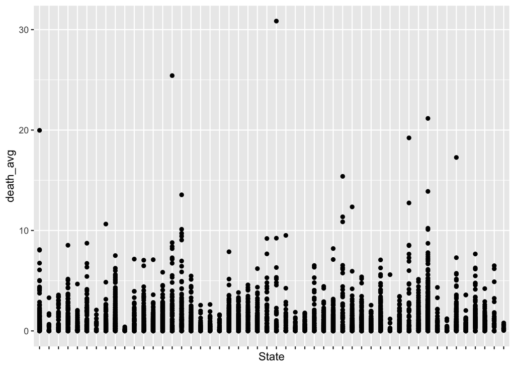

```r
cases_mask_data %>%
  mutate(State = fct_lump(state))%>%
  group_by(State)%>%
  summarise(death_avg = deaths_avg_per_100k) %>%
  ggplot(aes(x=State, y=death_avg))+
  geom_point()+ theme(
        axis.text.x=element_blank())
```

Although the average still appears to be similar across states, we can see there is much greater variation in death rates within states, as the range of the data is larger.

For mask usage, by state:

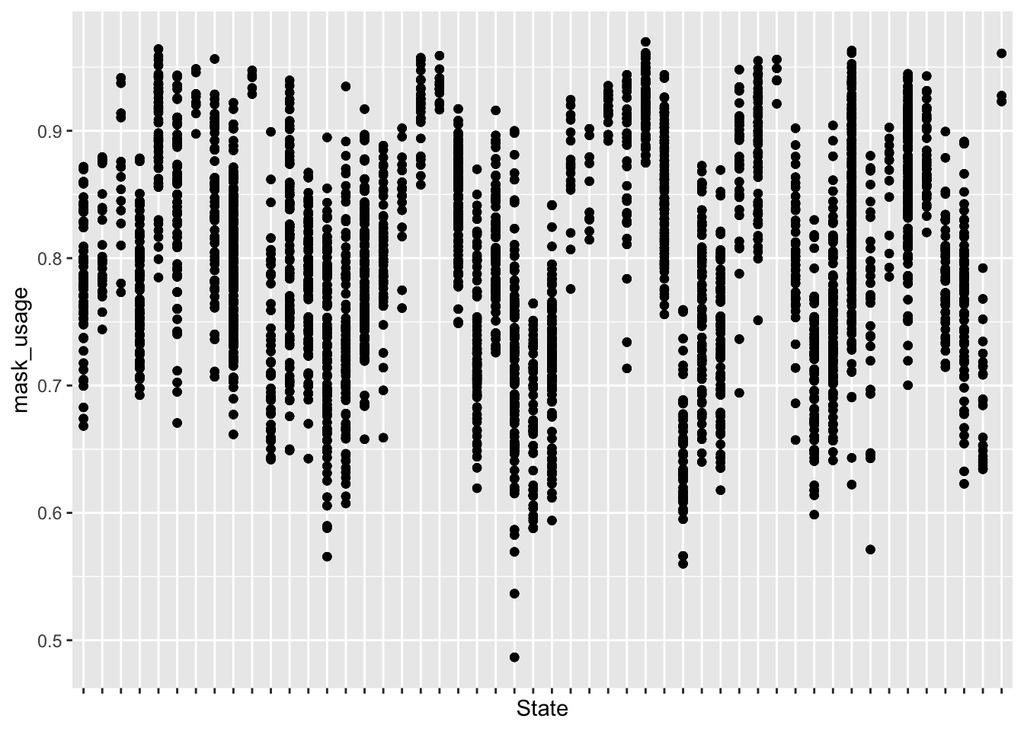

```r
cases_mask_data %>%
  mutate(State = fct_lump(state))%>%
  group_by(State)%>%
  summarise(mask_usage = mask_frequency) %>%
  ggplot(aes(x=State, y=mask_usage))+
  geom_point()+ theme(
        axis.text.x=element_blank())
```

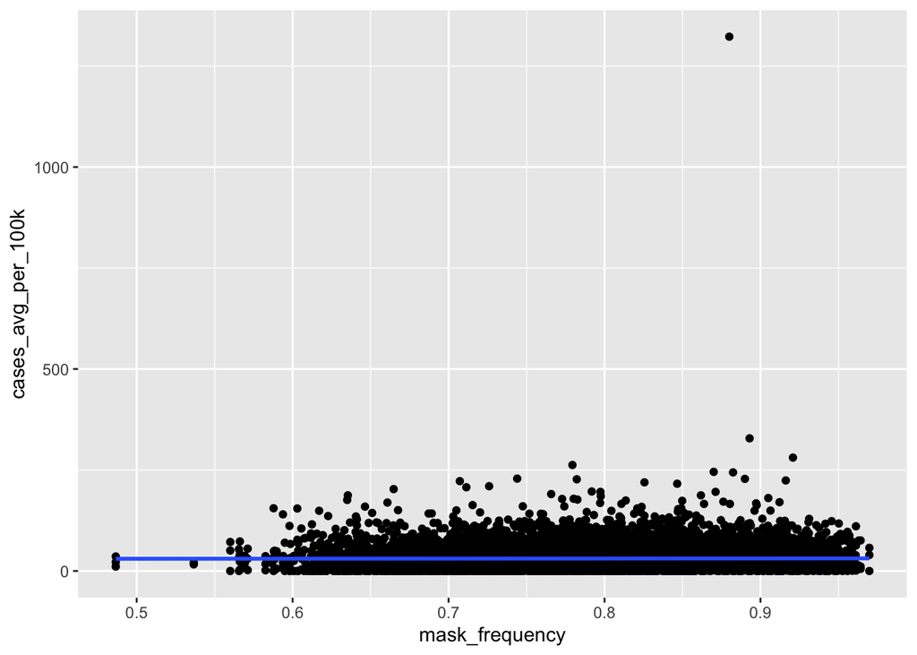

```r
# draw stratified graphs with smooth line
cases_mask_data %>%
  group_by(COUNTYFP)%>%
  ggplot(aes(x=mask_frequency,y=cases_avg_per_100k))+
  geom_point()+
  geom_smooth(method="lm", se=FALSE)
```

It appears that we have a large outlier, with more than 1000 cases per 100k of the population. This is making it difficult to analyze any trend in our data, as the rest of our data is clustered at much lower average case numbers. We can look at this data point more closely:

```r
cases_mask_data %>%
  filter(cases_avg_per_100k>1000)
```

```
##         date COUNTYFP county        state cases_avg_per_100k
## 1 2021-01-21    42053 Forest Pennsylvania            1322.71
##   deaths_avg_per_100k mask_frequency
## 1                3.07           0.88
```

We can see that this point is for the county of Forest, Pennsylvania. Looking up this county in the case data set:

```r
data %>% filter(COUNTYFP == '42053' &  (date == '2021-01-19' |date == '2021-01-20' | date == '2021-01-21'| date == '2021-01-22'| date == '2021-01-23'))%>%
  select(c('date','county','cases'))
```

```
##         date county cases
## 1 2021-01-19 Forest     0
## 2 2021-01-20 Forest     1
## 3 2021-01-21 Forest   514
## 4 2021-01-22 Forest     1
## 5 2021-01-23 Forest     0
```

From looking at the reported number of cases just before and after the date with the large case average, we can see that it appears to be a reporting bias, rather than such a large jump in cases. Although it could be a large outbreak, we would expect there to be an increased number of cases in the days preceding and in the days after our chosen date, however this is not the case. Therefore, it looks like there could have been a delay in reporting, with cases from a longer period all being recorded on a single day, making the average much higher than it otherwise would have been. Therefore, we can exclude this data point from our analysis, to see if there is a clearer trend without our regression being skewed by the outlier.

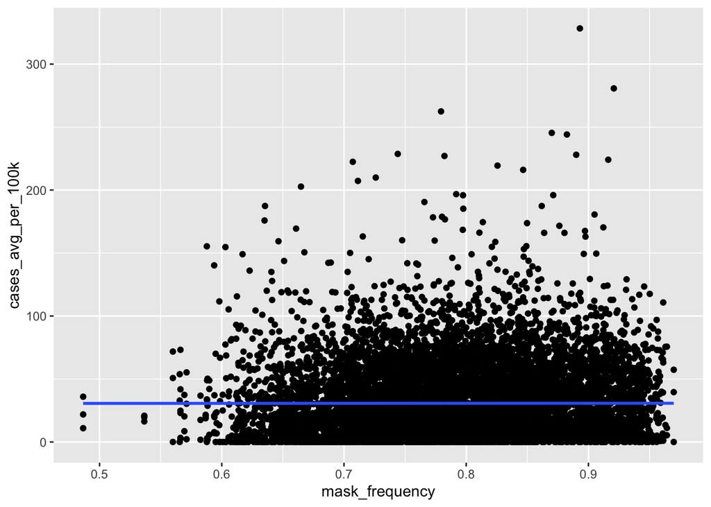

```r
# draw stratified graphs with smooth line
cases_mask_data %>%
  filter(cases_avg_per_100k<=1000)%>%
  group_by(COUNTYFP)%>%
  ggplot(aes(x=mask_frequency,y=cases_avg_per_100k))+
  geom_point()+
  geom_smooth(method="lm", se=FALSE)
```

We can also look at the average cases and deaths in the counties which report the lowest and highest proportion of people who “never” wear a mask, and who “always” where a mask, to see if this gives a clearer answer to whether there is a statistical relationship between wearing a mask and getting Covid, or indeed dying from it.

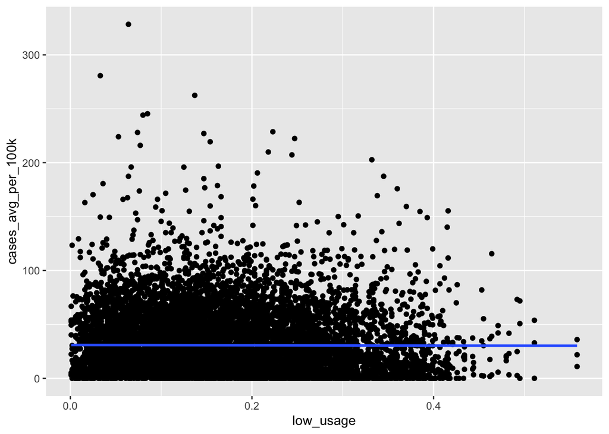

```r
full_cases_mask_data <- right_join(cases_data_filtered, mask_data_filtered, by=c ("COUNTYFP", "date","county", "state"))
full_cases_mask_data <- full_cases_mask_data %>% mutate(low_usage = full_cases_mask_data$NEVER + full_cases_mask_data$RARELY, high_usage = full_cases_mask_data$FREQUENTLY + full_cases_mask_data$ALWAYS)
# Plotting average cases per 100k against percentage who rarely or never wear masks
full_cases_mask_data %>%
  filter(cases_avg_per_100k<=1000)%>%
  group_by(COUNTYFP)%>%
  ggplot(aes(x=low_usage,y=cases_avg_per_100k))+
  geom_point()+
  geom_smooth(method="lm", se=FALSE)
```

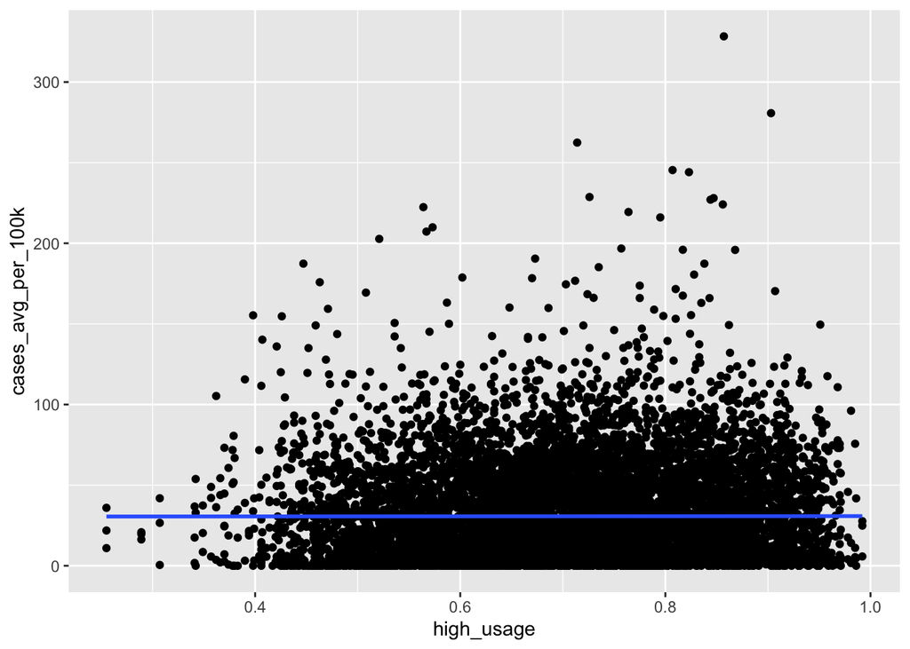

```r
# Plotting average cases per 100k against percentage who frequently or always wear masks
full_cases_mask_data %>%
  filter(cases_avg_per_100k<=1000)%>%
  group_by(COUNTYFP)%>%
  ggplot(aes(x=high_usage,y=cases_avg_per_100k))+
  geom_point()+
  geom_smooth(method="lm", se=FALSE)
```

Looking at the above scatter graphs, we can conclude that there does not seem to be a statistically significant correlation between mask usage and the average number of Covid cases.

Looking at deaths instead:

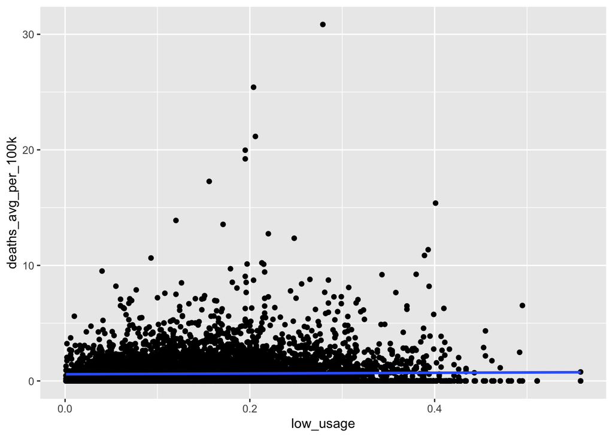

```r
# Plotting average deaths per 100k against percentage who rarely or never wear masks
full_cases_mask_data %>%
  filter(cases_avg_per_100k<=1000)%>%
  group_by(COUNTYFP)%>%
  ggplot(aes(x=low_usage,y=deaths_avg_per_100k))+
  geom_point()+
  geom_smooth(method="lm", se=FALSE)
```

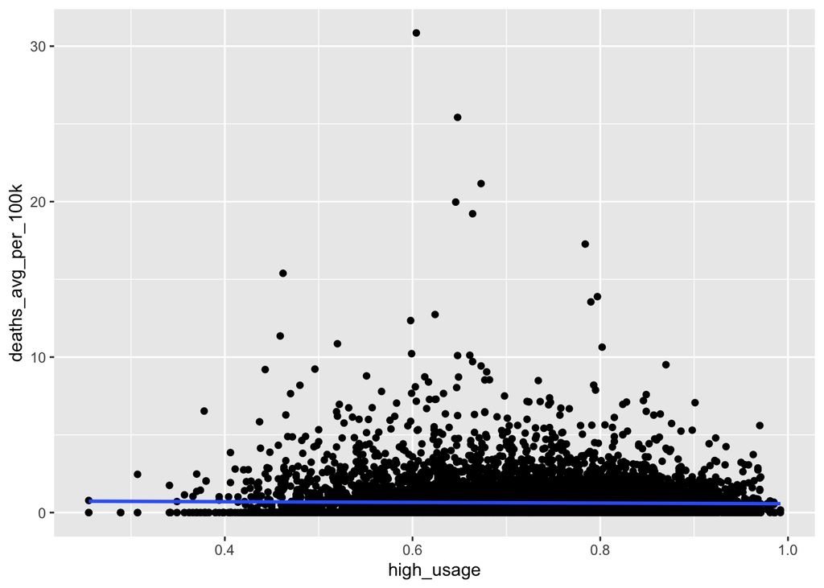

```r
# Plotting average deaths per 100k against percentage who frequently or always wear masks
full_cases_mask_data %>%
  filter(cases_avg_per_100k<=1000)%>%
  group_by(COUNTYFP)%>%
  ggplot(aes(x=high_usage,y=deaths_avg_per_100k))+
  geom_point()+
  geom_smooth(method="lm", se=FALSE)
```

Again, we do not seem to have a significant relationship between mask usage and the average number of deaths per 100k people. However, the counties with higher death rates do appear to report a lower mask usage. We can see that in the following graph:

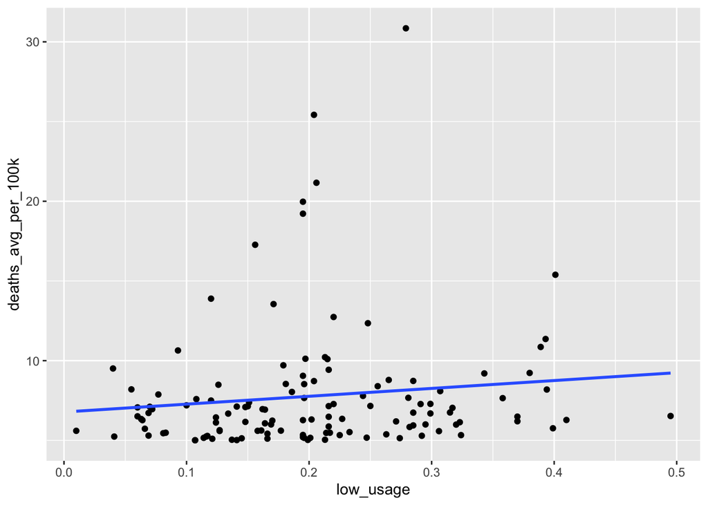

```r
# Plotting higher average deaths per 100k against percentage who rarely or never wear masks
full_cases_mask_data %>%
  filter(deaths_avg_per_100k>5)%>%
  group_by(COUNTYFP)%>%
  ggplot(aes(x=low_usage,y=deaths_avg_per_100k))+
  geom_point()+geom_smooth(method="lm", se=FALSE)
```

Therefore, it seems like some other factors could be influencing death rate, causing it to remain low regardless of mask usage. We can look at death rate on a map, to see if geographic location (i.e. whether a county is rural or near a big city) affects death rate.

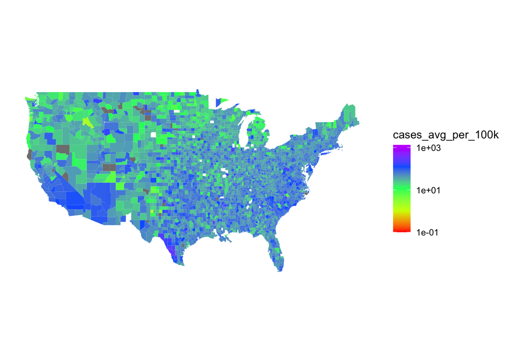

```r
county_df <- map_data("county")
full_cases_mask_data$subregion<-tolower(full_cases_mask_data$county)
map_mask_df<-right_join(county_df,full_cases_mask_data)
map_plot<-ggplot(map_mask_df)+ geom_polygon(aes(x=long,y=lat,fill= cases_avg_per_100k,group=group))+coord_fixed(1.3)+theme_bw()
remove_axis <- theme(
  axis.text = element_blank(),
  axis.line = element_blank(),
  axis.ticks = element_blank(),
  panel.border = element_blank(),
  panel.grid = element_blank(),
  axis.title = element_blank()
  )
map_plot +  scale_fill_gradientn(colours = rainbow(5) ,trans = "log10")+remove_axis
```

It seems like there are certain hotspots in the South and in Texas and California, which have high numbers of cases. Rural areas seem to consistently have a lower number of cases, whereas there is greater variation in urban areas.

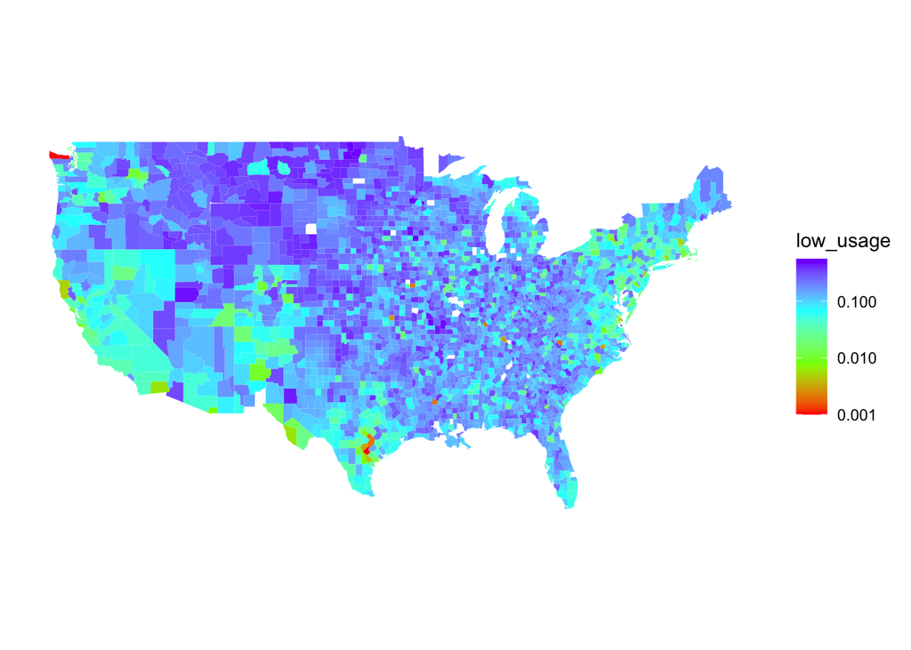

```r
map_plot<-ggplot(map_mask_df)+ geom_polygon(aes(x=long,y=lat,fill= low_usage,group=group))+coord_fixed(1.3)+theme_bw()
map_plot +  scale_fill_gradientn(colours = rainbow(4), trans = "log10")+remove_axis
```

It seems like in rural areas people wear masks less frequently. The higher the low_usage score in the graph above, the less the residents wear their mask.

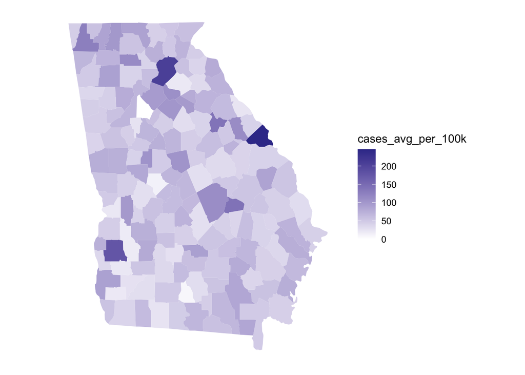

```r
georgia_data<- map_mask_df%>%filter(region=="georgia")
map_plot<-ggplot(georgia_data)+ geom_polygon(aes(x=long,y=lat,fill= cases_avg_per_100k,group=group))+coord_fixed(1.3)+theme_bw()
map_plot +  scale_fill_gradient2()+remove_axis
```

There are a few areas in Georgia which have a lot of cases, but most seem to have few.

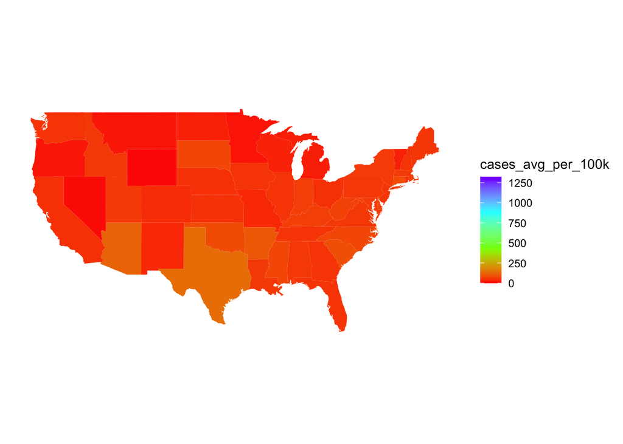

```r
state_df <- map_data("state")
full_cases_mask_data$region<-tolower(full_cases_mask_data$state)
map_mask_df<-inner_join(state_df,full_cases_mask_data,by=c("region"))
map_plot<-ggplot(map_mask_df)+ geom_polygon(aes(x=long,y=lat,fill=cases_avg_per_100k,group=group))+coord_fixed(1.3)+theme_bw()
map_plot + scale_fill_gradientn(colours = rainbow(4))+remove_axis
```

Looking at the data on a state level, instead of a county level,we can see that the average number of cases is low, and there is little variation between the states. In general, southern states appear to have more cases per 100k of the population that northern states.

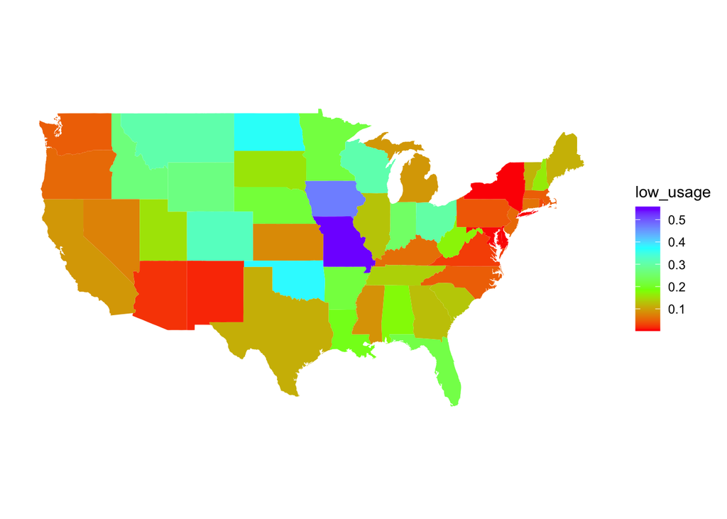

```r
state_df <- map_data("state")
full_cases_mask_data$region<-tolower(full_cases_mask_data$state)
map_mask_df<-inner_join(state_df,full_cases_mask_data,by=c("region"))
map_plot<-ggplot(map_mask_df)+ geom_polygon(aes(x=long,y=lat,fill= low_usage,group=group))+coord_fixed(1.3)+theme_bw()
map_plot +  scale_fill_gradientn(colours = rainbow(4))+remove_axis
```

There does, however, seem to be a much greater variation in mask usage across states. It seems that more densely populated states report a higher mask usage (and thus have a lower low_usage score) than states with a more rural population. However, this does not correspond with the states with the highest case rates, therefore we cannot observe a clear link between mask usage and Covid cases from our data set.

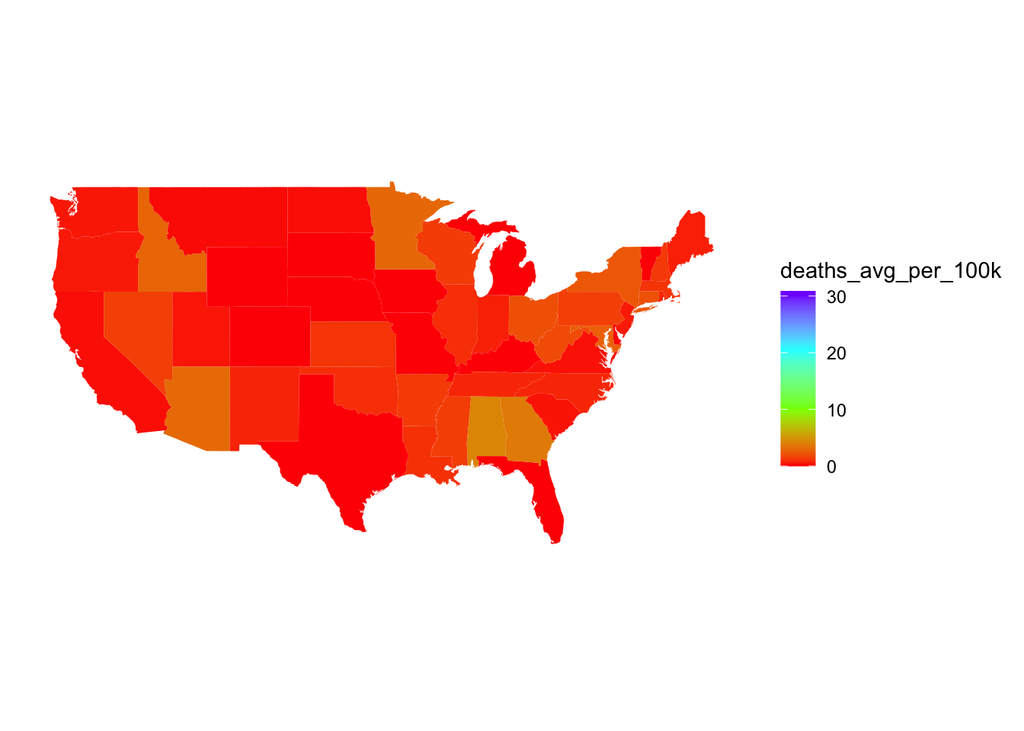

```r
state_df <- map_data("state")
full_cases_mask_data$region<-tolower(full_cases_mask_data$state)
map_mask_df<-inner_join(state_df,full_cases_mask_data,by=c("region"))
map_plot<-ggplot(map_mask_df)+ geom_polygon(aes(x=long,y=lat,fill= deaths_avg_per_100k,group=group))+coord_fixed(1.3)+theme_bw()
map_plot +  scale_fill_gradientn(colours = rainbow(4))+remove_axis
```

Despite this, we do not have clear, statistically significant evidence that mask usage leads to a lower case or death rate from Covid. There are a number of factors which could be causing this, such as people choosing to wear masks more frequently as cases increase, making mask usage higher in areas with higher Covid rates, or rural areas having a lower prevalence of Covid, as less people travel there, despite mask rates being low, as people feel more sheltered from the virus. Overall, we can say that mask usage does vary across states, and even within states, in the US, however both case and death rates have much less variation across the country. Another possible reason for this could be vaccine rates, as this can affect both the likelihood of someone getting covid, and of that person wearing a mask.